# CVIS Indicator Standardization Methods

Climate vulnerability indicators are standardized between a scale of 0 and 1 to improve comparability, facilitate interpretation and represent risk based on mechanistic relationships and thresholds. This is done by applying a standardization function to map the raw values to a standardized scale.

The standardization methods were adapted from those developed by Boyce et al (2023) [https://www.nature.com/articles/s41558-022-01437-y].

All standardized values are between 0 and 1, with 0 indicating the lowest risk and 1 indicating the highest risk. There are several different standardization functions that are applied depending on the raw indicator values and the mechanisms affecting risk. Functions can standardize risk based on the range of observed raw values, or using thresholds to represent physiological and other mechanisms.

The functions are:

**Positive standardization functions -** higher raw indicator value corresponds to higher standardized risk

**1. Linear positive standardization function -** raw value is rescaled between 0 to 1 using a linear relationship based on minimum and maximum values.  
equation 1 : y = (x - xmin) / (xmax - xmin)

**2. Logarithmic standardization function -** logarithmic increase in the standardized value up to an asymptote of 1.  
equation 2: y = 1 - exp(-lambda * x_std) + exp(-lambda) * x_std where x_std represents x rescaled between 0 and 1 using equation 1.

**3. Exponential increase standardization function -** exponential increase in the standardized value from 0 to 1. equation 3: y = exp(lambda * x_std)/exp(lambda) - exp(-lambda)*(1-x_std) where x_std represents x rescaled between 0 and 1 using equation 1.

**4. Stepwise standardization function -** stepwise increase in the standardized value based on thresholds.

**5. Categorical standardization function -** standardized value based on categories of raw values.

**Negative standardization functions -** higher raw indicator value corresponds to lower standardized risk

**6. Linear negative standardization function -** raw value is rescaled between 0 and 1 using an inverse linear relationship based on minimum and maximum values. equation 4: y = 1 - (z - xmin) / (xmax - xmin)

**7. Exponential decay standardization function -** exponential decrease in the standardized value from 1 to 0. The inverse of the logarithmic growth standardization function. equation 5: y = exp(-lambda * x_std) - exp(-lambda) * x_std where x_std represents x rescaled between 0 and 1 using equation 4.

## Plots of standardization functions

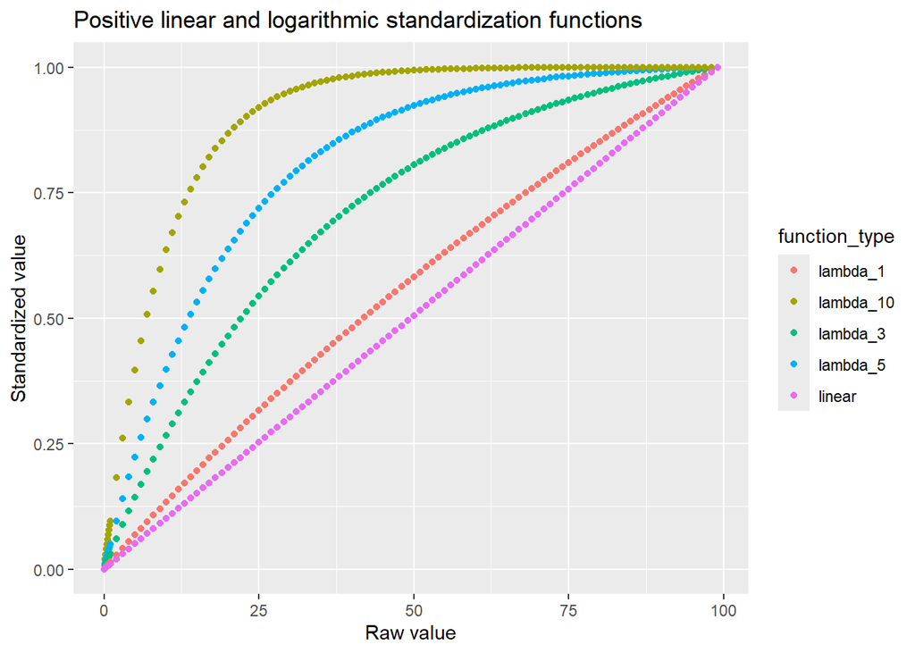

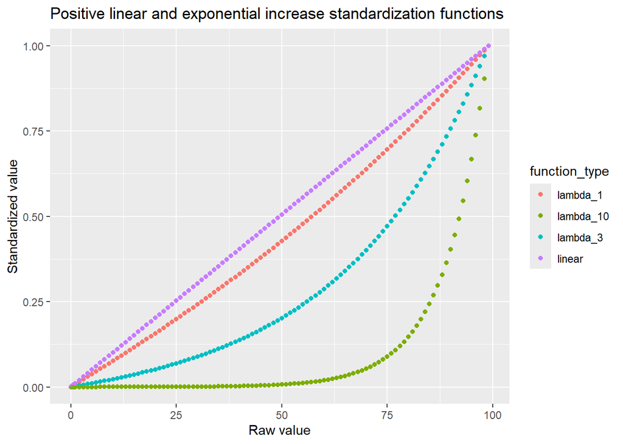

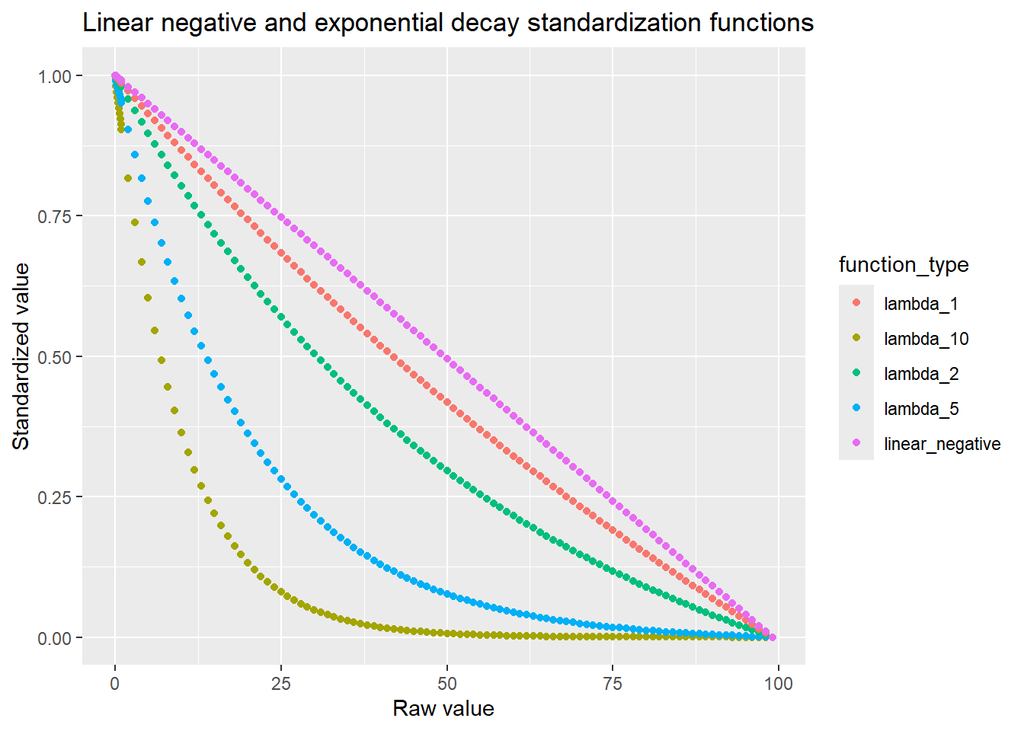

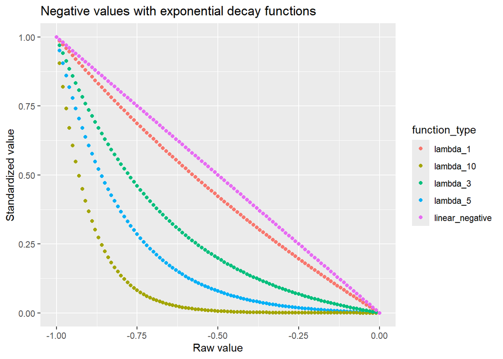

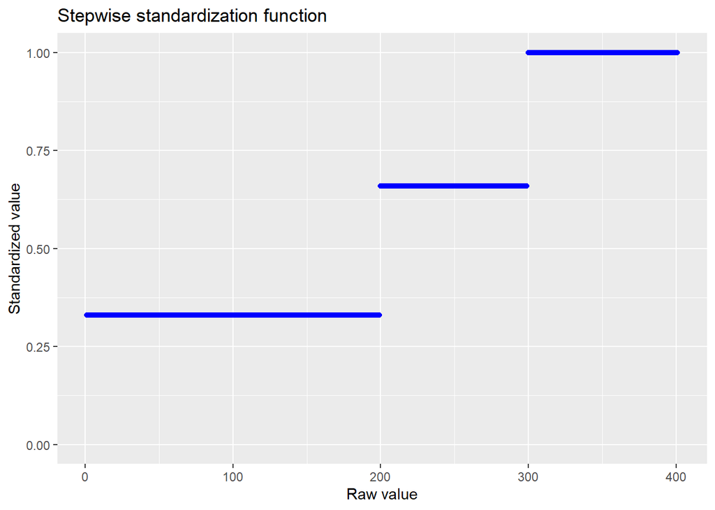